# Helen Margfoy - Problem set 4

# Problem Set 4

Para resolver este problem set, deberá poner en práctica los conocimientos adquiridos en la clase de webscraping y gestionar la información GIS que extraerá de internet. Finalmente, empleará R-Markdown para generar un HTML que posteriormente podrá publicar en su página de GitHub.

```r
# Cargar las librerías necesarias
library(rvest)
library(data.table)
library(sf)
library(ggplot2)
library(viridis)
```

## Extraer la información de internet (50%)

Primero, debe dirigirse a la página https://eduard-martinez.github.io/pset-4.html y examinar su contenido.

### 1.1 Obtener las URL

Cree un objeto llamdo url_full que almacene el vector de URLs contenidas en la página ../pset-4.html

```r
# Especificar la URL de la página
page_url <- "https://eduard-martinez.github.io/pset-4.html"

# Leer el contenido de la página
page_content <- read_html(page_url)

# Extraer todas las URL contenidas en la página
url_full <- page_content %>%
  html_nodes("a") %>%
  html_attr("href")

# Mostrar las URL obtenidas
print(url_full)
```

```
  [1] "index.html"
  [2] "index.html"
  [3] "research.html"
  [4] "https://eduard-martinez.github.io/cv/CV-Eduard_F_Martinez_G.pdf"
  [5] "teaching.html"
  [6] "blog.html"
  [7] "databases.html"
  [8] "https://eduard-martinez.github.io/pset-4/propiedad_1.html"
  [9] "https://eduard-martinez.github.io/pset-4/propiedad_2.html"
 [10] "https://eduard-martinez.github.io/pset-4/propiedad_3.html"
 [11] "https://eduard-martinez.github.io/pset-4/propiedad_4.html"
 [12] "https://eduard-martinez.github.io/pset-4/propiedad_5.html"
 [13] "https://eduard-martinez.github.io/pset-4/propiedad_6.html"
 [14] "https://eduard-martinez.github.io/pset-4/propiedad_7.html"
 [15] "https://eduard-martinez.github.io/pset-4/propiedad_8.html"
```

[output cut: 212 more lines]

### 1.2 Filtrar URL:

Del objeto url_full mantenga únicamente las URLs que contengan la palabra propiedad, guarde el resultado en un objeto llamado url_subset.

```r
# Filtrar las URLs que contienen la palabra "propiedad"
url_subset <- url_full[grepl("propiedad", url_full)]

# Mostrar las URLs filtradas
print(url_subset)
```

```
  [1] "https://eduard-martinez.github.io/pset-4/propiedad_1.html"   "https://eduard-martinez.github.io/pset-4/propiedad_2.html"
  [3] "https://eduard-martinez.github.io/pset-4/propiedad_3.html"   "https://eduard-martinez.github.io/pset-4/propiedad_4.html"
  [5] "https://eduard-martinez.github.io/pset-4/propiedad_5.html"   "https://eduard-martinez.github.io/pset-4/propiedad_6.html"
  [7] "https://eduard-martinez.github.io/pset-4/propiedad_7.html"   "https://eduard-martinez.github.io/pset-4/propiedad_8.html"
  [9] "https://eduard-martinez.github.io/pset-4/propiedad_9.html"   "https://eduard-martinez.github.io/pset-4/propiedad_10.html"
 [11] "https://eduard-martinez.github.io/pset-4/propiedad_11.html"  "https://eduard-martinez.github.io/pset-4/propiedad_12.html"
 [13] "https://eduard-martinez.github.io/pset-4/propiedad_13.html"  "https://eduard-martinez.github.io/pset-4/propiedad_14.html"
 [15] "https://eduard-martinez.github.io/pset-4/propiedad_15.html"  "https://eduard-martinez.github.io/pset-4/propiedad_16.html"
 [17] "https://eduard-martinez.github.io/pset-4/propiedad_17.html"  "https://eduard-martinez.github.io/pset-4/propiedad_18.html"
 [19] "https://eduard-martinez.github.io/pset-4/propiedad_19.html"  "https://eduard-martinez.github.io/pset-4/propiedad_20.html"
 [21] "https://eduard-martinez.github.io/pset-4/propiedad_21.html"  "https://eduard-martinez.github.io/pset-4/propiedad_22.html"
 [23] "https://eduard-martinez.github.io/pset-4/propiedad_23.html"  "https://eduard-martinez.github.io/pset-4/propiedad_24.html"
 [25] "https://eduard-martinez.github.io/pset-4/propiedad_25.html"  "https://eduard-martinez.github.io/pset-4/propiedad_26.html"
 [27] "https://eduard-martinez.github.io/pset-4/propiedad_27.html"  "https://eduard-martinez.github.io/pset-4/propiedad_28.html"
 [29] "https://eduard-martinez.github.io/pset-4/propiedad_29.html"  "https://eduard-martinez.github.io/pset-4/propiedad_30.html"
```

[output cut: 95 more lines]

### 1.3 Extraer las tablas de los HTML:

Utilice un bucle o función que itere sobre todos los elementos del objeto url_subset. Para cada URL, extraiga de su correspondiente HTML la tabla que contiene la información de las coordenadas y el precio de la propiedad. Almacene el resultado de este loop en un objeto tipo lista llamado lista_tablas.

```r
# Inicializar una lista para almacenar las tablas
lista_tablas <- list()

# Iterar sobre las URLs para extraer las tablas
for (i in seq_along(url_subset)) {
  # Leer la página de cada URL
  page <- read_html(url_subset[i])

  # Extraer la tabla
  table <- page %>%
    html_node("table") %>%
    html_table()

  # Agregar la tabla a la lista
  lista_tablas[[i]] <- table
}


# Mostrar las tablas obtenidas
print(lista_tablas)
```

|  | V1 | rooms | bedrooms | bathrooms | surface_total | surface_covered | price | property_type | lat | lon | geometry |
| --- | --- | --- | --- | --- | --- | --- | --- | --- | --- | --- | --- |
| 162357 | 162357 | NA | 3 | 3 | 115 | NA | 6.4e+08 | Apartamento | 4.717989 | -74.07909 | POINT (-74.07909 4.717989) |

|  | V1 | rooms | bedrooms | bathrooms | surface_total | surface_covered | price | property_type | lat | lon | geometry |
| --- | --- | --- | --- | --- | --- | --- | --- | --- | --- | --- | --- |
| 209310 | 209310 | NA | NA | 2 | NA | NA | 1.75e+08 | Otro | 4.76 | -74.034 | POINT (-74.034 4.76) |

|  | V1 | rooms | bedrooms | bathrooms | surface_total | surface_covered | price | property_type | lat | lon | geometry |
| --- | --- | --- | --- | --- | --- | --- | --- | --- | --- | --- | --- |
| 139333 | 139333 | NA | NA | NA | NA | NA | 3.99e+08 | Apartamento | 4.588 | -74.11 | POINT (-74.11 4.588) |

|  | V1 | rooms | bedrooms | bathrooms | surface_total | surface_covered | price | property_type | lat | lon | geometry |
| --- | --- | --- | --- | --- | --- | --- | --- | --- | --- | --- | --- |
| 161433 | 161433 | NA | NA | 6 | 822 | NA | 3.6e+09 | Depósito | 4.666264 | -74.08338 | POINT (-74.08338 4.666264) |

|  | V1 | rooms | bedrooms | bathrooms | surface_total | surface_covered | price | property_type | lat | lon | geometry |
| --- | --- | --- | --- | --- | --- | --- | --- | --- | --- | --- | --- |
| 140273 | 140273 | 6 | 6 | 3 | 253 | 370 | 5e+08 | Casa | 4.733 | -74.089 | POINT (-74.089 4.733) |

|  | V1 | rooms | bedrooms | bathrooms | surface_total | surface_covered | price | property_type | lat | lon | geometry |
| --- | --- | --- | --- | --- | --- | --- | --- | --- | --- | --- | --- |
| 203282 | 203282 | NA | 3 | 2 | NA | NA | 2.6e+08 | Apartamento | 4.768361 | -74.04681 | POINT (-74.04681 4.768361) |

|  | V1 | rooms | bedrooms | bathrooms | surface_total | surface_covered | price | property_type | lat | lon | geometry |
| --- | --- | --- | --- | --- | --- | --- | --- | --- | --- | --- | --- |
| 197741 | 197741 | 4 | 4 | 4 | 280 | 280 | 2.8e+09 | Apartamento | 4.685 | -74.027 | POINT (-74.027 4.685) |

|  | V1 | rooms | bedrooms | bathrooms | surface_total | surface_covered | price | property_type | lat | lon | geometry |
| --- | --- | --- | --- | --- | --- | --- | --- | --- | --- | --- | --- |
| 135130 | 135130 | NA | 3 | 4 | NA | NA | 8.75e+08 | Apartamento | 4.697425 | -74.03502 | POINT (-74.03502 4.697425) |

|  | V1 | rooms | bedrooms | bathrooms | surface_total | surface_covered | price | property_type | lat | lon | geometry |
| --- | --- | --- | --- | --- | --- | --- | --- | --- | --- | --- | --- |
| 185192 | 185192 | NA | NA | 4 | NA | NA | 2.3e+09 | Apartamento | 4.716734 | -74.03451 | POINT (-74.03451 4.716734) |

|  | V1 | rooms | bedrooms | bathrooms | surface_total | surface_covered | price | property_type | lat | lon | geometry |
| --- | --- | --- | --- | --- | --- | --- | --- | --- | --- | --- | --- |
| 54089 | 54089 | 3 | 3 | NA | NA | NA | 4.35e+08 | Apartamento | 4.658833 | -74.11119 | POINT (-74.11119 4.658833) |

|  | V1 | rooms | bedrooms | bathrooms | surface_total | surface_covered | price | property_type | lat | lon | geometry |
| --- | --- | --- | --- | --- | --- | --- | --- | --- | --- | --- | --- |
| 217818 | 217818 | NA | NA | 3 | NA | NA | 6.8e+08 | Apartamento | 4.700977 | -74.03351 | POINT (-74.03351 4.700977) |

|  | V1 | rooms | bedrooms | bathrooms | surface_total | surface_covered | price | property_type | lat | lon | geometry |
| --- | --- | --- | --- | --- | --- | --- | --- | --- | --- | --- | --- |
| 205647 | 205647 | NA | 3 | 4 | NA | NA | 1.23e+09 | Apartamento | 4.717339 | -74.08106 | POINT (-74.08106 4.717339) |

|  | V1 | rooms | bedrooms | bathrooms | surface_total | surface_covered | price | property_type | lat | lon | geometry |
| --- | --- | --- | --- | --- | --- | --- | --- | --- | --- | --- | --- |
| 817 | 817 | 2 | 2 | NA | NA | NA | 6.4e+08 | Apartamento | 4.69331 | -74.04647 | POINT (-74.04647 4.69331) |

|  | V1 | rooms | bedrooms | bathrooms | surface_total | surface_covered | price | property_type | lat | lon | geometry |
| --- | --- | --- | --- | --- | --- | --- | --- | --- | --- | --- | --- |
| 189436 | 189436 | NA | NA | NA | NA | 97 | 4.2e+08 | Oficina | 4.63738 | -74.06122 | POINT (-74.06122 4.63738) |

|  | V1 | rooms | bedrooms | bathrooms | surface_total | surface_covered | price | property_type | lat | lon | geometry |
| --- | --- | --- | --- | --- | --- | --- | --- | --- | --- | --- | --- |
| 159351 | 159351 | 3 | 3 | 2 | NA | 59 | 2.4e+08 | Apartamento | 4.666 | -74.137 | POINT (-74.137 4.666) |

|  | V1 | rooms | bedrooms | bathrooms | surface_total | surface_covered | price | property_type | lat | lon | geometry |
| --- | --- | --- | --- | --- | --- | --- | --- | --- | --- | --- | --- |
| 199781 | 199781 | 3 | 3 | 1 | 57 | 57 | 1.7e+08 | Apartamento | 4.729 | -74.088 | POINT (-74.088 4.729) |

|  | V1 | rooms | bedrooms | bathrooms | surface_total | surface_covered | price | property_type | lat | lon | geometry |
| --- | --- | --- | --- | --- | --- | --- | --- | --- | --- | --- | --- |
| 45958 | 45958 | NA | NA | 1 | NA | NA | 149900000 | Casa | 4.609 | -74.206 | POINT (-74.206 4.609) |

|  | V1 | rooms | bedrooms | bathrooms | surface_total | surface_covered | price | property_type | lat | lon | geometry |
| --- | --- | --- | --- | --- | --- | --- | --- | --- | --- | --- | --- |
| 6626 | 6626 | NA | NA | 2 | NA | NA | 4.5e+08 | Apartamento | 4.703032 | -74.03029 | POINT (-74.03029 4.703032) |

|  | V1 | rooms | bedrooms | bathrooms | surface_total | surface_covered | price | property_type | lat | lon | geometry |
| --- | --- | --- | --- | --- | --- | --- | --- | --- | --- | --- | --- |
| 85065 | 85065 | 2 | 2 | NA | NA | NA | 8.3e+08 | Apartamento | 4.649675 | -74.05361 | POINT (-74.05361 4.649675) |

|  | V1 | rooms | bedrooms | bathrooms | surface_total | surface_covered | price | property_type | lat | lon | geometry |
| --- | --- | --- | --- | --- | --- | --- | --- | --- | --- | --- | --- |
| 169548 | 169548 | NA | 3 | 2 | 151 | NA | 5.5e+08 | Otro | 4.758 | -74.057 | POINT (-74.057 4.758) |

|  | V1 | rooms | bedrooms | bathrooms | surface_total | surface_covered | price | property_type | lat | lon | geometry |
| --- | --- | --- | --- | --- | --- | --- | --- | --- | --- | --- | --- |
| 67634 | 67634 | 2 | NA | 2 | NA | 80 | 3.3e+08 | Apartamento | 4.728067 | -74.04262 | POINT (-74.04262 4.728067) |

|  | V1 | rooms | bedrooms | bathrooms | surface_total | surface_covered | price | property_type | lat | lon | geometry |
| --- | --- | --- | --- | --- | --- | --- | --- | --- | --- | --- | --- |
| 12224 | 12224 | NA | NA | 1 | NA | NA | 8.85e+08 | Casa | 4.74 | -74.054 | POINT (-74.054 4.74) |

|  | V1 | rooms | bedrooms | bathrooms | surface_total | surface_covered | price | property_type | lat | lon | geometry |
| --- | --- | --- | --- | --- | --- | --- | --- | --- | --- | --- | --- |
| 33773 | 33773 | NA | NA | 3 | NA | NA | 399900000 | Otro | 4.68 | -74.145 | POINT (-74.145 4.68) |

|  | V1 | rooms | bedrooms | bathrooms | surface_total | surface_covered | price | property_type | lat | lon | geometry |
| --- | --- | --- | --- | --- | --- | --- | --- | --- | --- | --- | --- |
| 36774 | 36774 | 2 | NA | 4 | 166 | 166 | 8.99e+08 | Apartamento | 4.657015 | -74.0478 | POINT (-74.0478 4.657015) |

|  | V1 | rooms | bedrooms | bathrooms | surface_total | surface_covered | price | property_type | lat | lon | geometry |
| --- | --- | --- | --- | --- | --- | --- | --- | --- | --- | --- | --- |
| 31464 | 31464 | 4 | 4 | NA | NA | NA | 2.95e+08 | Apartamento | 4.728584 | -74.03867 | POINT (-74.03867 4.728584) |

|  | V1 | rooms | bedrooms | bathrooms | surface_total | surface_covered | price | property_type | lat | lon | geometry |
| --- | --- | --- | --- | --- | --- | --- | --- | --- | --- | --- | --- |
| 21803 | 21803 | NA | NA | NA | NA | NA | 4.3e+08 | Oficina | 4.620229 | -74.07459 | POINT (-74.07459 4.620229) |

|  | V1 | rooms | bedrooms | bathrooms | surface_total | surface_covered | price | property_type | lat | lon | geometry |
| --- | --- | --- | --- | --- | --- | --- | --- | --- | --- | --- | --- |
| 134667 | 134667 | NA | 3 | 3 | NA | NA | 860444000 | Apartamento | 4.70291 | -74.02817 | POINT (-74.02817 4.70291) |

|  | V1 | rooms | bedrooms | bathrooms | surface_total | surface_covered | price | property_type | lat | lon | geometry |
| --- | --- | --- | --- | --- | --- | --- | --- | --- | --- | --- | --- |
| 208422 | 208422 | NA | NA | 1 | NA | NA | 3.5e+08 | Otro | 4.702 | -74.039 | POINT (-74.039 4.702) |

|  | V1 | rooms | bedrooms | bathrooms | surface_total | surface_covered | price | property_type | lat | lon | geometry |
| --- | --- | --- | --- | --- | --- | --- | --- | --- | --- | --- | --- |
| 47747 | 47747 | 4 | 4 | NA | NA | NA | 2.39e+08 | Casa | 4.751881 | -74.08532 | POINT (-74.08532 4.751881) |

|  | V1 | rooms | bedrooms | bathrooms | surface_total | surface_covered | price | property_type | lat | lon | geometry |
| --- | --- | --- | --- | --- | --- | --- | --- | --- | --- | --- | --- |
| 84152 | 84152 | 3 | NA | 2 | NA | 94 | 4.8e+08 | Apartamento | 4.706417 | -74.07605 | POINT (-74.07605 4.706417) |

|  | V1 | rooms | bedrooms | bathrooms | surface_total | surface_covered | price | property_type | lat | lon | geometry |
| --- | --- | --- | --- | --- | --- | --- | --- | --- | --- | --- | --- |
| 236163 | 236163 | NA | NA | 4 | 176 | 176 | 7.2e+08 | Apartamento | 4.694465 | -74.03598 | POINT (-74.03598 4.694465) |

|  | V1 | rooms | bedrooms | bathrooms | surface_total | surface_covered | price | property_type | lat | lon | geometry |
| --- | --- | --- | --- | --- | --- | --- | --- | --- | --- | --- | --- |
| 21845 | 21845 | NA | 3 | 2 | NA | NA | 5.68e+08 | Apartamento | 4.642599 | -74.05942 | POINT (-74.05942 4.642599) |

|  | V1 | rooms | bedrooms | bathrooms | surface_total | surface_covered | price | property_type | lat | lon | geometry |
| --- | --- | --- | --- | --- | --- | --- | --- | --- | --- | --- | --- |
| 210280 | 210280 | NA | NA | 2 | NA | NA | 3.1e+08 | Otro | 4.727 | -74.048 | POINT (-74.048 4.727) |

|  | V1 | rooms | bedrooms | bathrooms | surface_total | surface_covered | price | property_type | lat | lon | geometry |
| --- | --- | --- | --- | --- | --- | --- | --- | --- | --- | --- | --- |
| 2396 | 2396 | NA | NA | 2 | NA | NA | 129900000 | Casa | 4.716 | -74.094 | POINT (-74.094 4.716) |

|  | V1 | rooms | bedrooms | bathrooms | surface_total | surface_covered | price | property_type | lat | lon | geometry |
| --- | --- | --- | --- | --- | --- | --- | --- | --- | --- | --- | --- |
| 43567 | 43567 | 1 | NA | 2 | NA | 64 | 4.75e+08 | Apartamento | 4.68312 | -74.05322 | POINT (-74.05322 4.68312) |

|  | V1 | rooms | bedrooms | bathrooms | surface_total | surface_covered | price | property_type | lat | lon | geometry |
| --- | --- | --- | --- | --- | --- | --- | --- | --- | --- | --- | --- |
| 67967 | 67967 | NA | NA | 2 | NA | NA | 5.7e+08 | Apartamento | 4.706678 | -74.03082 | POINT (-74.03082 4.706678) |

|  | V1 | rooms | bedrooms | bathrooms | surface_total | surface_covered | price | property_type | lat | lon | geometry |
| --- | --- | --- | --- | --- | --- | --- | --- | --- | --- | --- | --- |
| 9406 | 9406 | NA | NA | 2 | NA | NA | 1.87e+08 | Apartamento | 4.559199 | -74.09147 | POINT (-74.09147 4.559199) |

|  | V1 | rooms | bedrooms | bathrooms | surface_total | surface_covered | price | property_type | lat | lon | geometry |
| --- | --- | --- | --- | --- | --- | --- | --- | --- | --- | --- | --- |
| 115129 | 115129 | NA | NA | 1 | NA | NA | 1.95e+08 | Otro | 4.668717 | -74.05574 | POINT (-74.05574 4.668717) |

|  | V1 | rooms | bedrooms | bathrooms | surface_total | surface_covered | price | property_type | lat | lon | geometry |
| --- | --- | --- | --- | --- | --- | --- | --- | --- | --- | --- | --- |
| 229876 | 229876 | 3 | NA | 4 | 142 | 142 | 1.15e+09 | Apartamento | 4.692504 | -74.04346 | POINT (-74.04346 4.692504) |

|  | V1 | rooms | bedrooms | bathrooms | surface_total | surface_covered | price | property_type | lat | lon | geometry |
| --- | --- | --- | --- | --- | --- | --- | --- | --- | --- | --- | --- |
| 210215 | 210215 | NA | NA | 2 | NA | NA | 3.7e+08 | Otro | 4.72 | -74.048 | POINT (-74.048 4.72) |

|  | V1 | rooms | bedrooms | bathrooms | surface_total | surface_covered | price | property_type | lat | lon | geometry |
| --- | --- | --- | --- | --- | --- | --- | --- | --- | --- | --- | --- |
| 197435 | 197435 | 3 | NA | 4 | 400 | 225 | 1.29e+09 | Casa | 4.716067 | -74.03924 | POINT (-74.03924 4.716067) |

|  | V1 | rooms | bedrooms | bathrooms | surface_total | surface_covered | price | property_type | lat | lon | geometry |
| --- | --- | --- | --- | --- | --- | --- | --- | --- | --- | --- | --- |
| 84035 | 84035 | 3 | 3 | 2 | 36 | 108 | 1.9e+08 | Casa | 4.722 | -74.103 | POINT (-74.103 4.722) |

|  | V1 | rooms | bedrooms | bathrooms | surface_total | surface_covered | price | property_type | lat | lon | geometry |
| --- | --- | --- | --- | --- | --- | --- | --- | --- | --- | --- | --- |
| 84104 | 84104 | NA | NA | NA | NA | NA | 1.6e+09 | Otro | 4.715797 | -74.07145 | POINT (-74.07145 4.715797) |

|  | V1 | rooms | bedrooms | bathrooms | surface_total | surface_covered | price | property_type | lat | lon | geometry |
| --- | --- | --- | --- | --- | --- | --- | --- | --- | --- | --- | --- |
| 128930 | 128930 | 3 | NA | 2 | NA | 82 | 3.6e+08 | Apartamento | 4.75481 | -74.04098 | POINT (-74.04098 4.75481) |

|  | V1 | rooms | bedrooms | bathrooms | surface_total | surface_covered | price | property_type | lat | lon | geometry |
| --- | --- | --- | --- | --- | --- | --- | --- | --- | --- | --- | --- |
| 123105 | 123105 | NA | 2 | 2 | 58 | NA | 1.9e+08 | Apartamento | 4.722 | -74.125 | POINT (-74.125 4.722) |

|  | V1 | rooms | bedrooms | bathrooms | surface_total | surface_covered | price | property_type | lat | lon | geometry |
| --- | --- | --- | --- | --- | --- | --- | --- | --- | --- | --- | --- |
| 169924 | 169924 | NA | 3 | 3 | 89 | NA | 3.5e+08 | Otro | 4.725 | -74.04 | POINT (-74.04 4.725) |

|  | V1 | rooms | bedrooms | bathrooms | surface_total | surface_covered | price | property_type | lat | lon | geometry |
| --- | --- | --- | --- | --- | --- | --- | --- | --- | --- | --- | --- |
| 53671 | 53671 | 4 | NA | 3 | NA | 120 | 5.6e+08 | Apartamento | 4.685789 | -74.043 | POINT (-74.043 4.685789) |

|  | V1 | rooms | bedrooms | bathrooms | surface_total | surface_covered | price | property_type | lat | lon | geometry |
| --- | --- | --- | --- | --- | --- | --- | --- | --- | --- | --- | --- |
| 192828 | 192828 | NA | NA | 3 | NA | NA | 8.2e+08 | Casa | 4.629 | -74.08 | POINT (-74.08 4.629) |

|  | V1 | rooms | bedrooms | bathrooms | surface_total | surface_covered | price | property_type | lat | lon | geometry |
| --- | --- | --- | --- | --- | --- | --- | --- | --- | --- | --- | --- |
| 227099 | 227099 | NA | NA | 4 | NA | NA | 7.5e+08 | Otro | 4.741 | -74.057 | POINT (-74.057 4.741) |

|  | V1 | rooms | bedrooms | bathrooms | surface_total | surface_covered | price | property_type | lat | lon | geometry |
| --- | --- | --- | --- | --- | --- | --- | --- | --- | --- | --- | --- |
| 45926 | 45926 | 2 | 2 | NA | NA | NA | 9e+08 | Apartamento | 4.677334 | -74.05319 | POINT (-74.05319 4.677334) |

|  | V1 | rooms | bedrooms | bathrooms | surface_total | surface_covered | price | property_type | lat | lon | geometry |
| --- | --- | --- | --- | --- | --- | --- | --- | --- | --- | --- | --- |
| 70177 | 70177 | NA | NA | 3 | NA | NA | 1.1e+09 | Apartamento | 4.712455 | -74.1272 | POINT (-74.1272 4.712455) |

|  | V1 | rooms | bedrooms | bathrooms | surface_total | surface_covered | price | property_type | lat | lon | geometry |
| --- | --- | --- | --- | --- | --- | --- | --- | --- | --- | --- | --- |
| 114017 | 114017 | NA | 4 | 1 | 58 | NA | 1.8e+08 | Casa | 4.642 | -74.156 | POINT (-74.156 4.642) |

|  | V1 | rooms | bedrooms | bathrooms | surface_total | surface_covered | price | property_type | lat | lon | geometry |
| --- | --- | --- | --- | --- | --- | --- | --- | --- | --- | --- | --- |
| 165257 | 165257 | NA | NA | 4 | 3340 | NA | 7.374e+09 | Depósito | 4.768858 | -74.03651 | POINT (-74.03651 4.768858) |

|  | V1 | rooms | bedrooms | bathrooms | surface_total | surface_covered | price | property_type | lat | lon | geometry |
| --- | --- | --- | --- | --- | --- | --- | --- | --- | --- | --- | --- |
| 91110 | 91110 | 3 | NA | 2 | NA | 110 | 4.45e+08 | Apartamento | 4.730518 | -74.03678 | POINT (-74.03678 4.730518) |

|  | V1 | rooms | bedrooms | bathrooms | surface_total | surface_covered | price | property_type | lat | lon | geometry |
| --- | --- | --- | --- | --- | --- | --- | --- | --- | --- | --- | --- |
| 236700 | 236700 | 3 | NA | 2 | NA | 52 | 3.2e+08 | Apartamento | 4.669539 | -74.11739 | POINT (-74.11739 4.669539) |

|  | V1 | rooms | bedrooms | bathrooms | surface_total | surface_covered | price | property_type | lat | lon | geometry |
| --- | --- | --- | --- | --- | --- | --- | --- | --- | --- | --- | --- |
| 26699 | 26699 | NA | NA | 1 | NA | NA | 1.1e+09 | Casa | 4.734 | -74.074 | POINT (-74.074 4.734) |

|  | V1 | rooms | bedrooms | bathrooms | surface_total | surface_covered | price | property_type | lat | lon | geometry |
| --- | --- | --- | --- | --- | --- | --- | --- | --- | --- | --- | --- |
| 115081 | 115081 | NA | NA | NA | NA | NA | 1.2e+08 | Otro | 4.619873 | -74.06884 | POINT (-74.06884 4.619873) |

|  | V1 | rooms | bedrooms | bathrooms | surface_total | surface_covered | price | property_type | lat | lon | geometry |
| --- | --- | --- | --- | --- | --- | --- | --- | --- | --- | --- | --- |
| 232312 | 232312 | NA | NA | NA | NA | NA | 1.9e+07 | Otro | 4.648282 | -74.12786 | POINT (-74.12786 4.648282) |

|  | V1 | rooms | bedrooms | bathrooms | surface_total | surface_covered | price | property_type | lat | lon | geometry |
| --- | --- | --- | --- | --- | --- | --- | --- | --- | --- | --- | --- |
| 135833 | 135833 | NA | NA | NA | NA | NA | 3.6e+09 | Otro | 4.742247 | -74.03828 | POINT (-74.03828 4.742247) |

|  | V1 | rooms | bedrooms | bathrooms | surface_total | surface_covered | price | property_type | lat | lon | geometry |
| --- | --- | --- | --- | --- | --- | --- | --- | --- | --- | --- | --- |
| 207086 | 207086 | 5 | 5 | NA | NA | 56 | 4e+08 | Oficina | 4.663 | -74.052 | POINT (-74.052 4.663) |

|  | V1 | rooms | bedrooms | bathrooms | surface_total | surface_covered | price | property_type | lat | lon | geometry |
| --- | --- | --- | --- | --- | --- | --- | --- | --- | --- | --- | --- |
| 52929 | 52929 | 5 | NA | 3 | NA | 180 | 4.3e+08 | Casa | 4.744401 | -74.12674 | POINT (-74.12674 4.744401) |

|  | V1 | rooms | bedrooms | bathrooms | surface_total | surface_covered | price | property_type | lat | lon | geometry |
| --- | --- | --- | --- | --- | --- | --- | --- | --- | --- | --- | --- |
| 75975 | 75975 | NA | NA | 2 | NA | NA | 4.9e+08 | Apartamento | 4.741011 | -74.05643 | POINT (-74.05643 4.741011) |

|  | V1 | rooms | bedrooms | bathrooms | surface_total | surface_covered | price | property_type | lat | lon | geometry |
| --- | --- | --- | --- | --- | --- | --- | --- | --- | --- | --- | --- |
| 188646 | 188646 | NA | 3 | 2 | 46 | NA | 1.55e+08 | Otro | 4.717615 | -74.13054 | POINT (-74.13054 4.717615) |

|  | V1 | rooms | bedrooms | bathrooms | surface_total | surface_covered | price | property_type | lat | lon | geometry |
| --- | --- | --- | --- | --- | --- | --- | --- | --- | --- | --- | --- |
| 109221 | 109221 | NA | NA | 3 | NA | NA | 4.2e+08 | Casa | 4.549 | -74.138 | POINT (-74.138 4.549) |

|  | V1 | rooms | bedrooms | bathrooms | surface_total | surface_covered | price | property_type | lat | lon | geometry |
| --- | --- | --- | --- | --- | --- | --- | --- | --- | --- | --- | --- |
| 59026 | 59026 | 2 | 2 | 2 | NA | 71 | 3.45e+08 | Apartamento | 4.733 | -74.075 | POINT (-74.075 4.733) |

|  | V1 | rooms | bedrooms | bathrooms | surface_total | surface_covered | price | property_type | lat | lon | geometry |
| --- | --- | --- | --- | --- | --- | --- | --- | --- | --- | --- | --- |
| 229942 | 229942 | NA | 2 | 3 | 81 | NA | 3.95e+08 | Apartamento | 4.702073 | -74.04366 | POINT (-74.04366 4.702073) |

|  | V1 | rooms | bedrooms | bathrooms | surface_total | surface_covered | price | property_type | lat | lon | geometry |
| --- | --- | --- | --- | --- | --- | --- | --- | --- | --- | --- | --- |
| 227555 | 227555 | NA | NA | 2 | NA | NA | 2.25e+08 | Otro | 4.654 | -74.151 | POINT (-74.151 4.654) |

|  | V1 | rooms | bedrooms | bathrooms | surface_total | surface_covered | price | property_type | lat | lon | geometry |
| --- | --- | --- | --- | --- | --- | --- | --- | --- | --- | --- | --- |
| 206491 | 206491 | NA | NA | NA | NA | NA | 304467638 | Otro | 4.645771 | -74.06514 | POINT (-74.06514 4.645771) |

|  | V1 | rooms | bedrooms | bathrooms | surface_total | surface_covered | price | property_type | lat | lon | geometry |
| --- | --- | --- | --- | --- | --- | --- | --- | --- | --- | --- | --- |
| 163277 | 163277 | NA | NA | 1 | NA | 45 | 3.8e+08 | Oficina | 4.681995 | -74.04985 | POINT (-74.04985 4.681994) |

|  | V1 | rooms | bedrooms | bathrooms | surface_total | surface_covered | price | property_type | lat | lon | geometry |
| --- | --- | --- | --- | --- | --- | --- | --- | --- | --- | --- | --- |
| 197304 | 197304 | 4 | NA | 4 | NA | 200 | 1.2e+09 | Apartamento | 4.689362 | -74.04741 | POINT (-74.04741 4.689362) |

|  | V1 | rooms | bedrooms | bathrooms | surface_total | surface_covered | price | property_type | lat | lon | geometry |
| --- | --- | --- | --- | --- | --- | --- | --- | --- | --- | --- | --- |
| 27038 | 27038 | 3 | 3 | 3 | 249 | 249 | 2.3e+09 | Apartamento | 4.679 | -74.053 | POINT (-74.053 4.679) |

|  | V1 | rooms | bedrooms | bathrooms | surface_total | surface_covered | price | property_type | lat | lon | geometry |
| --- | --- | --- | --- | --- | --- | --- | --- | --- | --- | --- | --- |
| 44383 | 44383 | 3 | NA | 3 | NA | 154 | 8.5e+08 | Apartamento | 4.700044 | -74.05118 | POINT (-74.05118 4.700044) |

|  | V1 | rooms | bedrooms | bathrooms | surface_total | surface_covered | price | property_type | lat | lon | geometry |
| --- | --- | --- | --- | --- | --- | --- | --- | --- | --- | --- | --- |
| 103537 | 103537 | 2 | 2 | 1 | 50 | 50 | 2.9e+08 | Apartamento | 4.633 | -74.095 | POINT (-74.095 4.633) |

|  | V1 | rooms | bedrooms | bathrooms | surface_total | surface_covered | price | property_type | lat | lon | geometry |
| --- | --- | --- | --- | --- | --- | --- | --- | --- | --- | --- | --- |
| 132348 | 132348 | NA | NA | 5 | NA | NA | 1e+09 | Casa | 4.741847 | -74.03983 | POINT (-74.03983 4.741847) |

|  | V1 | rooms | bedrooms | bathrooms | surface_total | surface_covered | price | property_type | lat | lon | geometry |
| --- | --- | --- | --- | --- | --- | --- | --- | --- | --- | --- | --- |
| 56058 | 56058 | NA | NA | 3 | NA | NA | 3.6e+08 | Casa | 4.648 | -74.067 | POINT (-74.067 4.648) |

|  | V1 | rooms | bedrooms | bathrooms | surface_total | surface_covered | price | property_type | lat | lon | geometry |
| --- | --- | --- | --- | --- | --- | --- | --- | --- | --- | --- | --- |
| 173922 | 173922 | NA | NA | 4 | NA | NA | 8.5e+08 | Apartamento | 4.695683 | -74.05217 | POINT (-74.05217 4.695683) |

|  | V1 | rooms | bedrooms | bathrooms | surface_total | surface_covered | price | property_type | lat | lon | geometry |
| --- | --- | --- | --- | --- | --- | --- | --- | --- | --- | --- | --- |
| 133957 | 133957 | NA | 2 | 2 | NA | NA | 5.5e+08 | Apartamento | 4.704917 | -74.03937 | POINT (-74.03937 4.704917) |

|  | V1 | rooms | bedrooms | bathrooms | surface_total | surface_covered | price | property_type | lat | lon | geometry |
| --- | --- | --- | --- | --- | --- | --- | --- | --- | --- | --- | --- |
| 161726 | 161726 | NA | NA | 6 | 660 | NA | 1.9e+09 | Depósito | 4.691498 | -74.09188 | POINT (-74.09188 4.691498) |

|  | V1 | rooms | bedrooms | bathrooms | surface_total | surface_covered | price | property_type | lat | lon | geometry |
| --- | --- | --- | --- | --- | --- | --- | --- | --- | --- | --- | --- |
| 126219 | 126219 | 3 | 3 | 2 | NA | 70 | 2.45e+08 | Casa | 4.759 | -74.04 | POINT (-74.04 4.759) |

|  | V1 | rooms | bedrooms | bathrooms | surface_total | surface_covered | price | property_type | lat | lon | geometry |
| --- | --- | --- | --- | --- | --- | --- | --- | --- | --- | --- | --- |
| 44564 | 44564 | 4 | 4 | 3 | 100 | 100 | 3.98e+08 | Casa | 4.726 | -74.057 | POINT (-74.057 4.726) |

|  | V1 | rooms | bedrooms | bathrooms | surface_total | surface_covered | price | property_type | lat | lon | geometry |
| --- | --- | --- | --- | --- | --- | --- | --- | --- | --- | --- | --- |
| 141310 | 141310 | NA | NA | 1 | NA | NA | 3.9e+08 | Otro | 4.662 | -74.059 | POINT (-74.059 4.662) |

|  | V1 | rooms | bedrooms | bathrooms | surface_total | surface_covered | price | property_type | lat | lon | geometry |
| --- | --- | --- | --- | --- | --- | --- | --- | --- | --- | --- | --- |
| 203004 | 203004 | NA | 3 | 2 | NA | NA | 3.85e+08 | Apartamento | 4.670333 | -74.10182 | POINT (-74.10182 4.670333) |

|  | V1 | rooms | bedrooms | bathrooms | surface_total | surface_covered | price | property_type | lat | lon | geometry |
| --- | --- | --- | --- | --- | --- | --- | --- | --- | --- | --- | --- |
| 210018 | 210018 | NA | NA | 2 | NA | NA | 6.95e+08 | Otro | 4.678 | -74.045 | POINT (-74.045 4.678) |

|  | V1 | rooms | bedrooms | bathrooms | surface_total | surface_covered | price | property_type | lat | lon | geometry |
| --- | --- | --- | --- | --- | --- | --- | --- | --- | --- | --- | --- |
| 107038 | 107038 | NA | NA | NA | NA | NA | 6e+08 | Casa | 4.7 | -74.092 | POINT (-74.092 4.7) |

|  | V1 | rooms | bedrooms | bathrooms | surface_total | surface_covered | price | property_type | lat | lon | geometry |
| --- | --- | --- | --- | --- | --- | --- | --- | --- | --- | --- | --- |
| 10749 | 10749 | NA | NA | 2 | NA | NA | 2.4e+08 | Casa | 4.713768 | -74.12132 | POINT (-74.12132 4.713768) |

|  | V1 | rooms | bedrooms | bathrooms | surface_total | surface_covered | price | property_type | lat | lon | geometry |
| --- | --- | --- | --- | --- | --- | --- | --- | --- | --- | --- | --- |
| 87789 | 87789 | NA | 2 | 2 | NA | NA | 4.65e+08 | Apartamento | 4.645572 | -74.06521 | POINT (-74.06521 4.645572) |

|  | V1 | rooms | bedrooms | bathrooms | surface_total | surface_covered | price | property_type | lat | lon | geometry |
| --- | --- | --- | --- | --- | --- | --- | --- | --- | --- | --- | --- |
| 94645 | 94645 | NA | 0 | NA | NA | NA | 3372500000 | Oficina | 4.698641 | -74.03056 | POINT (-74.03056 4.698641) |

|  | V1 | rooms | bedrooms | bathrooms | surface_total | surface_covered | price | property_type | lat | lon | geometry |
| --- | --- | --- | --- | --- | --- | --- | --- | --- | --- | --- | --- |
| 37006 | 37006 | NA | NA | 3 | NA | NA | 5.2e+08 | Apartamento | 4.738622 | -74.0601 | POINT (-74.0601 4.738622) |

|  | V1 | rooms | bedrooms | bathrooms | surface_total | surface_covered | price | property_type | lat | lon | geometry |
| --- | --- | --- | --- | --- | --- | --- | --- | --- | --- | --- | --- |
| 58731 | 58731 | NA | NA | 4 | NA | NA | 1e+09 | Otro | 4.727 | -74.064 | POINT (-74.064 4.727) |

|  | V1 | rooms | bedrooms | bathrooms | surface_total | surface_covered | price | property_type | lat | lon | geometry |
| --- | --- | --- | --- | --- | --- | --- | --- | --- | --- | --- | --- |
| 72296 | 72296 | 4 | 4 | 4 | 120 | 240 | 8e+08 | Casa | 4.649 | -74.117 | POINT (-74.117 4.649) |

|  | V1 | rooms | bedrooms | bathrooms | surface_total | surface_covered | price | property_type | lat | lon | geometry |
| --- | --- | --- | --- | --- | --- | --- | --- | --- | --- | --- | --- |
| 162675 | 162675 | NA | NA | NA | 187 | NA | 1779350000 | Oficina | 4.667961 | -74.11474 | POINT (-74.11474 4.667961) |

|  | V1 | rooms | bedrooms | bathrooms | surface_total | surface_covered | price | property_type | lat | lon | geometry |
| --- | --- | --- | --- | --- | --- | --- | --- | --- | --- | --- | --- |
| 16553 | 16553 | NA | NA | 3 | NA | NA | 6.3e+08 | Apartamento | 4.648849 | -74.08487 | POINT (-74.08487 4.648849) |

|  | V1 | rooms | bedrooms | bathrooms | surface_total | surface_covered | price | property_type | lat | lon | geometry |
| --- | --- | --- | --- | --- | --- | --- | --- | --- | --- | --- | --- |
| 217196 | 217196 | NA | 0 | NA | NA | NA | 4.5e+08 | Oficina | 4.676605 | -74.04543 | POINT (-74.04543 4.676605) |

|  | V1 | rooms | bedrooms | bathrooms | surface_total | surface_covered | price | property_type | lat | lon | geometry |
| --- | --- | --- | --- | --- | --- | --- | --- | --- | --- | --- | --- |
| 200272 | 200272 | NA | NA | NA | 273 | 273 | 3.5e+08 | Casa | 4.622398 | -74.19813 | POINT (-74.19813 4.622398) |

|  | V1 | rooms | bedrooms | bathrooms | surface_total | surface_covered | price | property_type | lat | lon | geometry |
| --- | --- | --- | --- | --- | --- | --- | --- | --- | --- | --- | --- |
| 81130 | 81130 | NA | NA | 1 | NA | NA | 84900000 | Casa | 4.642 | -74.166 | POINT (-74.166 4.642) |

|  | V1 | rooms | bedrooms | bathrooms | surface_total | surface_covered | price | property_type | lat | lon | geometry |
| --- | --- | --- | --- | --- | --- | --- | --- | --- | --- | --- | --- |
| 225978 | 225978 | NA | NA | 3 | NA | NA | 7.5e+08 | Otro | 4.685 | -74.051 | POINT (-74.051 4.685) |

|  | V1 | rooms | bedrooms | bathrooms | surface_total | surface_covered | price | property_type | lat | lon | geometry |
| --- | --- | --- | --- | --- | --- | --- | --- | --- | --- | --- | --- |
| 210740 | 210740 | NA | NA | 2 | NA | NA | 2.55e+08 | Otro | 4.722862 | -74.03914 | POINT (-74.03914 4.722862) |

|  | V1 | rooms | bedrooms | bathrooms | surface_total | surface_covered | price | property_type | lat | lon | geometry |
| --- | --- | --- | --- | --- | --- | --- | --- | --- | --- | --- | --- |
| 53486 | 53486 | 1 | NA | 2 | NA | 74 | 3.55e+08 | Apartamento | 4.721076 | -74.03573 | POINT (-74.03573 4.721076) |

|  | V1 | rooms | bedrooms | bathrooms | surface_total | surface_covered | price | property_type | lat | lon | geometry |
| --- | --- | --- | --- | --- | --- | --- | --- | --- | --- | --- | --- |
| 238480 | 238480 | 3 | 3 | 2 | 104 | 104 | 5.7e+08 | Apartamento | 4.7 | -74.03 | POINT (-74.03 4.7) |

|  | V1 | rooms | bedrooms | bathrooms | surface_total | surface_covered | price | property_type | lat | lon | geometry |
| --- | --- | --- | --- | --- | --- | --- | --- | --- | --- | --- | --- |
| 72243 | 72243 | 3 | NA | 3 | NA | 170 | 9e+08 | Parqueadero | 4.671202 | -74.06597 | POINT (-74.06597 4.671202) |

|  | V1 | rooms | bedrooms | bathrooms | surface_total | surface_covered | price | property_type | lat | lon | geometry |
| --- | --- | --- | --- | --- | --- | --- | --- | --- | --- | --- | --- |
| 135837 | 135837 | NA | NA | NA | NA | NA | 1.56e+10 | Oficina | 4.728144 | -74.02463 | POINT (-74.02463 4.728144) |

|  | V1 | rooms | bedrooms | bathrooms | surface_total | surface_covered | price | property_type | lat | lon | geometry |
| --- | --- | --- | --- | --- | --- | --- | --- | --- | --- | --- | --- |
| 173940 | 173940 | NA | NA | 4 | NA | NA | 1.25e+09 | Casa | 4.639865 | -74.09141 | POINT (-74.09141 4.639865) |

|  | V1 | rooms | bedrooms | bathrooms | surface_total | surface_covered | price | property_type | lat | lon | geometry |
| --- | --- | --- | --- | --- | --- | --- | --- | --- | --- | --- | --- |
| 26097 | 26097 | 3 | NA | 3 | 153 | 153 | 9.3e+08 | Apartamento | 4.708213 | -74.08175 | POINT (-74.08175 4.708213) |

|  | V1 | rooms | bedrooms | bathrooms | surface_total | surface_covered | price | property_type | lat | lon | geometry |
| --- | --- | --- | --- | --- | --- | --- | --- | --- | --- | --- | --- |
| 205237 | 205237 | NA | 8 | 4 | NA | NA | 1.3e+09 | Casa | 4.724156 | -74.04649 | POINT (-74.04649 4.724156) |

|  | V1 | rooms | bedrooms | bathrooms | surface_total | surface_covered | price | property_type | lat | lon | geometry |
| --- | --- | --- | --- | --- | --- | --- | --- | --- | --- | --- | --- |
| 131296 | 131296 | NA | 4 | 2 | 170 | NA | 2.8e+08 | Casa | 4.582 | -74.11 | POINT (-74.11 4.582) |

|  | V1 | rooms | bedrooms | bathrooms | surface_total | surface_covered | price | property_type | lat | lon | geometry |
| --- | --- | --- | --- | --- | --- | --- | --- | --- | --- | --- | --- |
| 12642 | 12642 | NA | NA | NA | NA | 430 | 1.75e+09 | Casa | 4.693447 | -74.09904 | POINT (-74.09904 4.693447) |

|  | V1 | rooms | bedrooms | bathrooms | surface_total | surface_covered | price | property_type | lat | lon | geometry |
| --- | --- | --- | --- | --- | --- | --- | --- | --- | --- | --- | --- |
| 113067 | 113067 | 3 | NA | 2 | NA | 74 | 4e+08 | Parqueadero | 4.671426 | -74.10999 | POINT (-74.10999 4.671426) |

|  | V1 | rooms | bedrooms | bathrooms | surface_total | surface_covered | price | property_type | lat | lon | geometry |
| --- | --- | --- | --- | --- | --- | --- | --- | --- | --- | --- | --- |
| 94101 | 94101 | NA | NA | 3 | NA | NA | 1.4e+09 | Apartamento | 4.658586 | -74.04878 | POINT (-74.04878 4.658586) |

|  | V1 | rooms | bedrooms | bathrooms | surface_total | surface_covered | price | property_type | lat | lon | geometry |
| --- | --- | --- | --- | --- | --- | --- | --- | --- | --- | --- | --- |
| 45683 | 45683 | 2 | NA | 3 | NA | 186 | 1.89e+09 | Apartamento | 4.662872 | -74.04695 | POINT (-74.04695 4.662872) |

|  | V1 | rooms | bedrooms | bathrooms | surface_total | surface_covered | price | property_type | lat | lon | geometry |
| --- | --- | --- | --- | --- | --- | --- | --- | --- | --- | --- | --- |
| 139772 | 139772 | NA | NA | 1 | NA | NA | 1.19e+08 | Casa | 4.663 | -74.147 | POINT (-74.147 4.663) |

|  | V1 | rooms | bedrooms | bathrooms | surface_total | surface_covered | price | property_type | lat | lon | geometry |
| --- | --- | --- | --- | --- | --- | --- | --- | --- | --- | --- | --- |
| 196373 | 196373 | 6 | 6 | 3 | NA | 230 | 4.2e+08 | Casa | 4.515 | -74.117 | POINT (-74.117 4.515) |

|  | V1 | rooms | bedrooms | bathrooms | surface_total | surface_covered | price | property_type | lat | lon | geometry |
| --- | --- | --- | --- | --- | --- | --- | --- | --- | --- | --- | --- |
| 146768 | 146768 | 2 | NA | 2 | NA | 50 | 1.35e+08 | Apartamento | 4.627094 | -74.17567 | POINT (-74.17567 4.627094) |

|  | V1 | rooms | bedrooms | bathrooms | surface_total | surface_covered | price | property_type | lat | lon | geometry |
| --- | --- | --- | --- | --- | --- | --- | --- | --- | --- | --- | --- |
| 112872 | 112872 | 3 | 3 | 1 | 55 | 55 | 8e+07 | Apartamento | 4.467 | -74.126 | POINT (-74.126 4.467) |

|  | V1 | rooms | bedrooms | bathrooms | surface_total | surface_covered | price | property_type | lat | lon | geometry |
| --- | --- | --- | --- | --- | --- | --- | --- | --- | --- | --- | --- |
| 2394 | 2394 | NA | NA | 2 | NA | NA | 3.99e+08 | Apartamento | 4.704094 | -74.07169 | POINT (-74.07169 4.704094) |

|  | V1 | rooms | bedrooms | bathrooms | surface_total | surface_covered | price | property_type | lat | lon | geometry |
| --- | --- | --- | --- | --- | --- | --- | --- | --- | --- | --- | --- |
| 198425 | 198425 | NA | 3 | 2 | 61 | NA | 2.5e+08 | Apartamento | 4.604 | -74.098 | POINT (-74.098 4.604) |

|  | V1 | rooms | bedrooms | bathrooms | surface_total | surface_covered | price | property_type | lat | lon | geometry |
| --- | --- | --- | --- | --- | --- | --- | --- | --- | --- | --- | --- |
| 70493 | 70493 | NA | NA | NA | 129 | 129 | 6e+08 | Casa | 4.633 | -74.154 | POINT (-74.154 4.633) |

|  | V1 | rooms | bedrooms | bathrooms | surface_total | surface_covered | price | property_type | lat | lon | geometry |
| --- | --- | --- | --- | --- | --- | --- | --- | --- | --- | --- | --- |
| 47994 | 47994 | NA | NA | NA | 626 | 626 | 6492255250 | Otro | 4.686 | -74.047 | POINT (-74.047 4.686) |

|  | V1 | rooms | bedrooms | bathrooms | surface_total | surface_covered | price | property_type | lat | lon | geometry |
| --- | --- | --- | --- | --- | --- | --- | --- | --- | --- | --- | --- |
| 177622 | 177622 | 2 | NA | 3 | 92 | 89 | 5.29e+08 | Apartamento | 4.722641 | -74.04811 | POINT (-74.04811 4.722641) |

|  | V1 | rooms | bedrooms | bathrooms | surface_total | surface_covered | price | property_type | lat | lon | geometry |
| --- | --- | --- | --- | --- | --- | --- | --- | --- | --- | --- | --- |
| 169925 | 169925 | NA | 3 | 3 | 89 | NA | 5.6e+08 | Otro | 4.703 | -74.033 | POINT (-74.033 4.703) |

|  | V1 | rooms | bedrooms | bathrooms | surface_total | surface_covered | price | property_type | lat | lon | geometry |
| --- | --- | --- | --- | --- | --- | --- | --- | --- | --- | --- | --- |
| 1826 | 1826 | 4 | NA | 3 | NA | 215 | 9.2e+08 | Casa | 4.652111 | -74.09123 | POINT (-74.09123 4.652111) |

|  | V1 | rooms | bedrooms | bathrooms | surface_total | surface_covered | price | property_type | lat | lon | geometry |
| --- | --- | --- | --- | --- | --- | --- | --- | --- | --- | --- | --- |
| 81176 | 81176 | NA | NA | 10 | NA | NA | 2.6e+09 | Otro | 4.694 | -74.066 | POINT (-74.066 4.694) |

|  | V1 | rooms | bedrooms | bathrooms | surface_total | surface_covered | price | property_type | lat | lon | geometry |
| --- | --- | --- | --- | --- | --- | --- | --- | --- | --- | --- | --- |
| 87928 | 87928 | NA | NA | 2 | NA | NA | 1.65e+08 | Apartamento | 4.678277 | -74.07717 | POINT (-74.07717 4.678277) |

|  | V1 | rooms | bedrooms | bathrooms | surface_total | surface_covered | price | property_type | lat | lon | geometry |
| --- | --- | --- | --- | --- | --- | --- | --- | --- | --- | --- | --- |
| 238654 | 238654 | NA | 3 | 3 | 103 | NA | 695365000 | Apartamento | 4.722924 | -74.04939 | POINT (-74.04939 4.722924) |

|  | V1 | rooms | bedrooms | bathrooms | surface_total | surface_covered | price | property_type | lat | lon | geometry |
| --- | --- | --- | --- | --- | --- | --- | --- | --- | --- | --- | --- |
| 172386 | 172386 | NA | NA | 2 | 68 | NA | 4.5e+08 | Oficina | 4.668011 | -74.0677 | POINT (-74.0677 4.668011) |

|  | V1 | rooms | bedrooms | bathrooms | surface_total | surface_covered | price | property_type | lat | lon | geometry |
| --- | --- | --- | --- | --- | --- | --- | --- | --- | --- | --- | --- |
| 187368 | 187368 | NA | NA | NA | NA | NA | 3.72e+10 | Otro | 4.704 | -74.054 | POINT (-74.054 4.704) |

|  | V1 | rooms | bedrooms | bathrooms | surface_total | surface_covered | price | property_type | lat | lon | geometry |
| --- | --- | --- | --- | --- | --- | --- | --- | --- | --- | --- | --- |
| 199945 | 199945 | 3 | NA | 3 | NA | 171 | 5.7e+08 | Casa | 4.73971 | -74.06506 | POINT (-74.06506 4.73971) |

|  | V1 | rooms | bedrooms | bathrooms | surface_total | surface_covered | price | property_type | lat | lon | geometry |
| --- | --- | --- | --- | --- | --- | --- | --- | --- | --- | --- | --- |
| 170866 | 170866 | NA | NA | 4 | 1120 | NA | 2.4e+09 | Depósito | 4.589723 | -74.21875 | POINT (-74.21875 4.589723) |

|  | V1 | rooms | bedrooms | bathrooms | surface_total | surface_covered | price | property_type | lat | lon | geometry |
| --- | --- | --- | --- | --- | --- | --- | --- | --- | --- | --- | --- |
| 79383 | 79383 | 3 | 3 | 2 | NA | 480 | 2e+09 | Oficina | 4.633 | -74.075 | POINT (-74.075 4.633) |

|  | V1 | rooms | bedrooms | bathrooms | surface_total | surface_covered | price | property_type | lat | lon | geometry |
| --- | --- | --- | --- | --- | --- | --- | --- | --- | --- | --- | --- |
| 123406 | 123406 | NA | 7 | 4 | 213 | NA | 4.95e+08 | Casa | 4.596 | -74.142 | POINT (-74.142 4.596) |

|  | V1 | rooms | bedrooms | bathrooms | surface_total | surface_covered | price | property_type | lat | lon | geometry |
| --- | --- | --- | --- | --- | --- | --- | --- | --- | --- | --- | --- |
| 91265 | 91265 | NA | NA | 1 | NA | NA | 2.8e+08 | Otro | 4.740502 | -74.03561 | POINT (-74.03561 4.740502) |

|  | V1 | rooms | bedrooms | bathrooms | surface_total | surface_covered | price | property_type | lat | lon | geometry |
| --- | --- | --- | --- | --- | --- | --- | --- | --- | --- | --- | --- |
| 55542 | 55542 | NA | NA | 1 | NA | NA | 169900000 | Casa | 4.565 | -74.081 | POINT (-74.081 4.565) |

|  | V1 | rooms | bedrooms | bathrooms | surface_total | surface_covered | price | property_type | lat | lon | geometry |
| --- | --- | --- | --- | --- | --- | --- | --- | --- | --- | --- | --- |
| 136137 | 136137 | NA | NA | 1 | NA | NA | 7.5e+09 | Otro | 4.670359 | -74.1384 | POINT (-74.1384 4.670359) |

|  | V1 | rooms | bedrooms | bathrooms | surface_total | surface_covered | price | property_type | lat | lon | geometry |
| --- | --- | --- | --- | --- | --- | --- | --- | --- | --- | --- | --- |
| 144414 | 144414 | NA | NA | 8 | NA | NA | 449900000 | Casa | 4.563 | -74.099 | POINT (-74.099 4.563) |

|  | V1 | rooms | bedrooms | bathrooms | surface_total | surface_covered | price | property_type | lat | lon | geometry |
| --- | --- | --- | --- | --- | --- | --- | --- | --- | --- | --- | --- |
| 33043 | 33043 | NA | NA | NA | NA | NA | 2.205e+09 | Local comercial | 4.645837 | -74.06306 | POINT (-74.06306 4.645837) |

|  | V1 | rooms | bedrooms | bathrooms | surface_total | surface_covered | price | property_type | lat | lon | geometry |
| --- | --- | --- | --- | --- | --- | --- | --- | --- | --- | --- | --- |
| 91672 | 91672 | 1 | 1 | NA | NA | NA | 2.2e+08 | Apartamento | 4.72887 | -74.04882 | POINT (-74.04882 4.72887) |

|  | V1 | rooms | bedrooms | bathrooms | surface_total | surface_covered | price | property_type | lat | lon | geometry |
| --- | --- | --- | --- | --- | --- | --- | --- | --- | --- | --- | --- |
| 9325 | 9325 | NA | NA | 2 | NA | NA | 3.6e+08 | Apartamento | 4.695 | -74.065 | POINT (-74.065 4.695) |

|  | V1 | rooms | bedrooms | bathrooms | surface_total | surface_covered | price | property_type | lat | lon | geometry |
| --- | --- | --- | --- | --- | --- | --- | --- | --- | --- | --- | --- |
| 99564 | 99564 | NA | NA | 2 | NA | NA | 3.15e+08 | Apartamento | 4.738216 | -74.06152 | POINT (-74.06152 4.738216) |

|  | V1 | rooms | bedrooms | bathrooms | surface_total | surface_covered | price | property_type | lat | lon | geometry |
| --- | --- | --- | --- | --- | --- | --- | --- | --- | --- | --- | --- |
| 125229 | 125229 | 3 | NA | 2 | NA | 102 | 5.17e+08 | Apartamento | 4.684924 | -74.0444 | POINT (-74.0444 4.684924) |

|  | V1 | rooms | bedrooms | bathrooms | surface_total | surface_covered | price | property_type | lat | lon | geometry |
| --- | --- | --- | --- | --- | --- | --- | --- | --- | --- | --- | --- |
| 94488 | 94488 | 3 | 3 | 3 | 108 | 108 | 5.3e+08 | Apartamento | 4.716 | -74.043 | POINT (-74.043 4.716) |

|  | V1 | rooms | bedrooms | bathrooms | surface_total | surface_covered | price | property_type | lat | lon | geometry |
| --- | --- | --- | --- | --- | --- | --- | --- | --- | --- | --- | --- |
| 85133 | 85133 | NA | NA | 2 | NA | NA | 3.98e+08 | Apartamento | 4.671103 | -74.11105 | POINT (-74.11105 4.671103) |

|  | V1 | rooms | bedrooms | bathrooms | surface_total | surface_covered | price | property_type | lat | lon | geometry |
| --- | --- | --- | --- | --- | --- | --- | --- | --- | --- | --- | --- |
| 103955 | 103955 | NA | 2 | 3 | 108 | NA | 8.5e+08 | Apartamento | 4.601 | -74.081 | POINT (-74.081 4.601) |

|  | V1 | rooms | bedrooms | bathrooms | surface_total | surface_covered | price | property_type | lat | lon | geometry |
| --- | --- | --- | --- | --- | --- | --- | --- | --- | --- | --- | --- |
| 84653 | 84653 | 1 | NA | 1 | NA | 75 | 4.4e+08 | Apartamento | 4.653101 | -74.05071 | POINT (-74.05071 4.653101) |

|  | V1 | rooms | bedrooms | bathrooms | surface_total | surface_covered | price | property_type | lat | lon | geometry |
| --- | --- | --- | --- | --- | --- | --- | --- | --- | --- | --- | --- |
| 233101 | 233101 | 1 | NA | 1 | 35 | 35 | 3.3e+08 | Apartamento | 4.697873 | -74.03747 | POINT (-74.03747 4.697873) |

|  | V1 | rooms | bedrooms | bathrooms | surface_total | surface_covered | price | property_type | lat | lon | geometry |
| --- | --- | --- | --- | --- | --- | --- | --- | --- | --- | --- | --- |
| 99376 | 99376 | NA | NA | NA | NA | NA | 1.65e+09 | Apartamento | 4.690899 | -74.04441 | POINT (-74.04441 4.690899) |

|  | V1 | rooms | bedrooms | bathrooms | surface_total | surface_covered | price | property_type | lat | lon | geometry |
| --- | --- | --- | --- | --- | --- | --- | --- | --- | --- | --- | --- |
| 77942 | 77942 | NA | NA | 2 | NA | NA | 1.39e+08 | Apartamento | 4.572445 | -74.09415 | POINT (-74.09415 4.572445) |

|  | V1 | rooms | bedrooms | bathrooms | surface_total | surface_covered | price | property_type | lat | lon | geometry |
| --- | --- | --- | --- | --- | --- | --- | --- | --- | --- | --- | --- |
| 109867 | 109867 | NA | 2 | 1 | 43 | NA | 1.25e+08 | Apartamento | 4.74 | -74.084 | POINT (-74.084 4.74) |

|  | V1 | rooms | bedrooms | bathrooms | surface_total | surface_covered | price | property_type | lat | lon | geometry |
| --- | --- | --- | --- | --- | --- | --- | --- | --- | --- | --- | --- |
| 23839 | 23839 | 3 | NA | 4 | 120 | 120 | 5.68e+08 | Apartamento | 4.695102 | -74.06155 | POINT (-74.06155 4.695102) |

|  | V1 | rooms | bedrooms | bathrooms | surface_total | surface_covered | price | property_type | lat | lon | geometry |
| --- | --- | --- | --- | --- | --- | --- | --- | --- | --- | --- | --- |
| 34655 | 34655 | NA | NA | 2 | NA | NA | 298900000 | Casa | 4.612 | -74.195 | POINT (-74.195 4.612) |

|  | V1 | rooms | bedrooms | bathrooms | surface_total | surface_covered | price | property_type | lat | lon | geometry |
| --- | --- | --- | --- | --- | --- | --- | --- | --- | --- | --- | --- |
| 98047 | 98047 | NA | NA | 2 | NA | NA | 2.8e+08 | Apartamento | 4.728576 | -74.0296 | POINT (-74.0296 4.728576) |

|  | V1 | rooms | bedrooms | bathrooms | surface_total | surface_covered | price | property_type | lat | lon | geometry |
| --- | --- | --- | --- | --- | --- | --- | --- | --- | --- | --- | --- |
| 173529 | 173529 | NA | NA | NA | NA | NA | 2.7e+08 | Otro | 4.718273 | -74.03397 | POINT (-74.03397 4.718273) |

|  | V1 | rooms | bedrooms | bathrooms | surface_total | surface_covered | price | property_type | lat | lon | geometry |
| --- | --- | --- | --- | --- | --- | --- | --- | --- | --- | --- | --- |
| 225944 | 225944 | NA | NA | NA | NA | NA | 5.5e+08 | Otro | 4.665878 | -74.06034 | POINT (-74.06034 4.665878) |

|  | V1 | rooms | bedrooms | bathrooms | surface_total | surface_covered | price | property_type | lat | lon | geometry |
| --- | --- | --- | --- | --- | --- | --- | --- | --- | --- | --- | --- |
| 231395 | 231395 | NA | 3 | 2 | 77 | NA | 3.25e+08 | Apartamento | 4.742478 | -74.06553 | POINT (-74.06553 4.742478) |

|  | V1 | rooms | bedrooms | bathrooms | surface_total | surface_covered | price | property_type | lat | lon | geometry |
| --- | --- | --- | --- | --- | --- | --- | --- | --- | --- | --- | --- |
| 200122 | 200122 | NA | NA | NA | 300 | 600 | 1.5e+09 | Local comercial | 4.614753 | -74.13261 | POINT (-74.13261 4.614753) |

|  | V1 | rooms | bedrooms | bathrooms | surface_total | surface_covered | price | property_type | lat | lon | geometry |
| --- | --- | --- | --- | --- | --- | --- | --- | --- | --- | --- | --- |
| 202931 | 202931 | NA | 3 | 2 | NA | NA | 1.8e+08 | Casa | 4.724256 | -74.13625 | POINT (-74.13625 4.724256) |

|  | V1 | rooms | bedrooms | bathrooms | surface_total | surface_covered | price | property_type | lat | lon | geometry |
| --- | --- | --- | --- | --- | --- | --- | --- | --- | --- | --- | --- |
| 115428 | 115428 | NA | NA | NA | NA | NA | 1.8e+08 | Otro | 4.591 | -74.186 | POINT (-74.186 4.591) |

|  | V1 | rooms | bedrooms | bathrooms | surface_total | surface_covered | price | property_type | lat | lon | geometry |
| --- | --- | --- | --- | --- | --- | --- | --- | --- | --- | --- | --- |
| 92549 | 92549 | NA | NA | 3 | NA | NA | 8.5e+08 | Apartamento | 4.653862 | -74.11372 | POINT (-74.11372 4.653862) |

|  | V1 | rooms | bedrooms | bathrooms | surface_total | surface_covered | price | property_type | lat | lon | geometry |
| --- | --- | --- | --- | --- | --- | --- | --- | --- | --- | --- | --- |
| 165509 | 165509 | 3 | NA | 4 | 250 | 250 | 1.2e+09 | Apartamento | 4.718129 | -74.07642 | POINT (-74.07642 4.718129) |

|  | V1 | rooms | bedrooms | bathrooms | surface_total | surface_covered | price | property_type | lat | lon | geometry |
| --- | --- | --- | --- | --- | --- | --- | --- | --- | --- | --- | --- |
| 4919 | 4919 | 3 | 3 | 4 | 236 | 236 | 1.58e+09 | Apartamento | 4.661 | -74.047 | POINT (-74.047 4.661) |

|  | V1 | rooms | bedrooms | bathrooms | surface_total | surface_covered | price | property_type | lat | lon | geometry |
| --- | --- | --- | --- | --- | --- | --- | --- | --- | --- | --- | --- |
| 121566 | 121566 | 1 | 1 | 2 | NA | 46 | 3.3e+08 | Apartamento | 4.646 | -74.065 | POINT (-74.065 4.646) |

|  | V1 | rooms | bedrooms | bathrooms | surface_total | surface_covered | price | property_type | lat | lon | geometry |
| --- | --- | --- | --- | --- | --- | --- | --- | --- | --- | --- | --- |
| 162463 | 162463 | 3 | NA | 2 | NA | 70 | 2.68e+08 | Apartamento | 4.643127 | -74.13678 | POINT (-74.13678 4.643127) |

|  | V1 | rooms | bedrooms | bathrooms | surface_total | surface_covered | price | property_type | lat | lon | geometry |
| --- | --- | --- | --- | --- | --- | --- | --- | --- | --- | --- | --- |
| 28520 | 28520 | 4 | NA | 6 | 711 | 295 | 1.2e+09 | Casa | 4.819964 | -74.06802 | POINT (-74.06802 4.819964) |

|  | V1 | rooms | bedrooms | bathrooms | surface_total | surface_covered | price | property_type | lat | lon | geometry |
| --- | --- | --- | --- | --- | --- | --- | --- | --- | --- | --- | --- |
| 53485 | 53485 | 1 | NA | 2 | NA | 74 | 3.7e+08 | Apartamento | 4.721011 | -74.0356 | POINT (-74.0356 4.721011) |

|  | V1 | rooms | bedrooms | bathrooms | surface_total | surface_covered | price | property_type | lat | lon | geometry |
| --- | --- | --- | --- | --- | --- | --- | --- | --- | --- | --- | --- |
| 158498 | 158498 | 3 | 3 | NA | NA | NA | 2.45e+08 | Apartamento | 4.73967 | -74.04345 | POINT (-74.04345 4.73967) |

|  | V1 | rooms | bedrooms | bathrooms | surface_total | surface_covered | price | property_type | lat | lon | geometry |
| --- | --- | --- | --- | --- | --- | --- | --- | --- | --- | --- | --- |
| 63649 | 63649 | NA | 3 | 2 | 62 | NA | 2.4e+08 | Apartamento | 4.641437 | -74.12863 | POINT (-74.12863 4.641437) |

|  | V1 | rooms | bedrooms | bathrooms | surface_total | surface_covered | price | property_type | lat | lon | geometry |
| --- | --- | --- | --- | --- | --- | --- | --- | --- | --- | --- | --- |
| 33141 | 33141 | 3 | 3 | NA | NA | NA | 5.3e+08 | Casa | 4.766491 | -74.04543 | POINT (-74.04543 4.766491) |

|  | V1 | rooms | bedrooms | bathrooms | surface_total | surface_covered | price | property_type | lat | lon | geometry |
| --- | --- | --- | --- | --- | --- | --- | --- | --- | --- | --- | --- |
| 22938 | 22938 | 3 | 3 | NA | NA | NA | 9.25e+08 | Apartamento | 4.715998 | -74.03169 | POINT (-74.03169 4.715998) |

|  | V1 | rooms | bedrooms | bathrooms | surface_total | surface_covered | price | property_type | lat | lon | geometry |
| --- | --- | --- | --- | --- | --- | --- | --- | --- | --- | --- | --- |
| 33830 | 33830 | NA | NA | 6 | NA | NA | 1.199e+09 | Otro | 4.657 | -74.072 | POINT (-74.072 4.657) |

|  | V1 | rooms | bedrooms | bathrooms | surface_total | surface_covered | price | property_type | lat | lon | geometry |
| --- | --- | --- | --- | --- | --- | --- | --- | --- | --- | --- | --- |
| 152568 | 152568 | 2 | NA | 1 | NA | 57 | 3e+08 | Apartamento | 4.618894 | -74.06875 | POINT (-74.06875 4.618894) |

|  | V1 | rooms | bedrooms | bathrooms | surface_total | surface_covered | price | property_type | lat | lon | geometry |
| --- | --- | --- | --- | --- | --- | --- | --- | --- | --- | --- | --- |
| 3151 | 3151 | NA | NA | 2 | NA | NA | 5.15e+08 | Apartamento | 4.717129 | -74.04318 | POINT (-74.04318 4.717129) |

|  | V1 | rooms | bedrooms | bathrooms | surface_total | surface_covered | price | property_type | lat | lon | geometry |
| --- | --- | --- | --- | --- | --- | --- | --- | --- | --- | --- | --- |
| 53978 | 53978 | NA | NA | NA | NA | 97 | 4.2e+08 | Oficina | 4.632068 | -74.06407 | POINT (-74.06407 4.632068) |

|  | V1 | rooms | bedrooms | bathrooms | surface_total | surface_covered | price | property_type | lat | lon | geometry |
| --- | --- | --- | --- | --- | --- | --- | --- | --- | --- | --- | --- |
| 157857 | 157857 | NA | NA | 1 | NA | NA | 1.9e+08 | Apartamento | 4.756283 | -74.02921 | POINT (-74.02921 4.756283) |

|  | V1 | rooms | bedrooms | bathrooms | surface_total | surface_covered | price | property_type | lat | lon | geometry |
| --- | --- | --- | --- | --- | --- | --- | --- | --- | --- | --- | --- |
| 37880 | 37880 | NA | NA | 1 | NA | NA | 1.68e+08 | Oficina | 4.604 | -74.088 | POINT (-74.088 4.604) |

|  | V1 | rooms | bedrooms | bathrooms | surface_total | surface_covered | price | property_type | lat | lon | geometry |
| --- | --- | --- | --- | --- | --- | --- | --- | --- | --- | --- | --- |
| 35538 | 35538 | 3 | NA | 2 | NA | 116 | 5.17e+08 | Apartamento | 4.675927 | -74.05251 | POINT (-74.05251 4.675927) |

|  | V1 | rooms | bedrooms | bathrooms | surface_total | surface_covered | price | property_type | lat | lon | geometry |
| --- | --- | --- | --- | --- | --- | --- | --- | --- | --- | --- | --- |
| 119707 | 119707 | NA | NA | 3 | NA | NA | 3.7e+08 | Otro | 4.658 | -74.096 | POINT (-74.096 4.658) |

|  | V1 | rooms | bedrooms | bathrooms | surface_total | surface_covered | price | property_type | lat | lon | geometry |
| --- | --- | --- | --- | --- | --- | --- | --- | --- | --- | --- | --- |
| 43768 | 43768 | 3 | NA | 3 | NA | 122 | 6e+08 | Apartamento | 4.72303 | -74.07316 | POINT (-74.07316 4.72303) |

|  | V1 | rooms | bedrooms | bathrooms | surface_total | surface_covered | price | property_type | lat | lon | geometry |
| --- | --- | --- | --- | --- | --- | --- | --- | --- | --- | --- | --- |
| 84689 | 84689 | 3 | NA | 3 | NA | 117 | 5.55e+08 | Apartamento | 4.723553 | -74.06286 | POINT (-74.06286 4.723553) |

|  | V1 | rooms | bedrooms | bathrooms | surface_total | surface_covered | price | property_type | lat | lon | geometry |
| --- | --- | --- | --- | --- | --- | --- | --- | --- | --- | --- | --- |
| 8481 | 8481 | NA | NA | 1 | 43 | 43 | 2.69e+08 | Oficina | 4.704 | -74.041 | POINT (-74.041 4.704) |

|  | V1 | rooms | bedrooms | bathrooms | surface_total | surface_covered | price | property_type | lat | lon | geometry |
| --- | --- | --- | --- | --- | --- | --- | --- | --- | --- | --- | --- |
| 44548 | 44548 | 3 | NA | 2 | NA | 118 | 5e+08 | Apartamento | 4.720064 | -74.07695 | POINT (-74.07695 4.720064) |

|  | V1 | rooms | bedrooms | bathrooms | surface_total | surface_covered | price | property_type | lat | lon | geometry |
| --- | --- | --- | --- | --- | --- | --- | --- | --- | --- | --- | --- |
| 77140 | 77140 | NA | NA | 2 | NA | 68 | 5.6e+08 | Oficina | 4.672941 | -74.05203 | POINT (-74.05203 4.672941) |

|  | V1 | rooms | bedrooms | bathrooms | surface_total | surface_covered | price | property_type | lat | lon | geometry |
| --- | --- | --- | --- | --- | --- | --- | --- | --- | --- | --- | --- |
| 124383 | 124383 | NA | NA | 4 | NA | NA | 1.8e+09 | Casa | 4.69 | -74.059 | POINT (-74.059 4.69) |

|  | V1 | rooms | bedrooms | bathrooms | surface_total | surface_covered | price | property_type | lat | lon | geometry |
| --- | --- | --- | --- | --- | --- | --- | --- | --- | --- | --- | --- |
| 156139 | 156139 | NA | NA | NA | NA | NA | 5e+07 | Lote | 4.581 | -74.048 | POINT (-74.048 4.581) |

|  | V1 | rooms | bedrooms | bathrooms | surface_total | surface_covered | price | property_type | lat | lon | geometry |
| --- | --- | --- | --- | --- | --- | --- | --- | --- | --- | --- | --- |
| 115188 | 115188 | NA | NA | 2 | NA | NA | 3e+08 | Casa | 4.667 | -74.113 | POINT (-74.113 4.667) |

|  | V1 | rooms | bedrooms | bathrooms | surface_total | surface_covered | price | property_type | lat | lon | geometry |
| --- | --- | --- | --- | --- | --- | --- | --- | --- | --- | --- | --- |
| 679 | 679 | 12 | 12 | 4 | 84 | 360 | 449990000 | Casa | 4.605 | -74.137 | POINT (-74.137 4.605) |

|  | V1 | rooms | bedrooms | bathrooms | surface_total | surface_covered | price | property_type | lat | lon | geometry |
| --- | --- | --- | --- | --- | --- | --- | --- | --- | --- | --- | --- |
| 136709 | 136709 | 3 | 3 | 2 | 69 | 69 | 2.75e+08 | Apartamento | 4.659 | -74.132 | POINT (-74.132 4.659) |

|  | V1 | rooms | bedrooms | bathrooms | surface_total | surface_covered | price | property_type | lat | lon | geometry |
| --- | --- | --- | --- | --- | --- | --- | --- | --- | --- | --- | --- |
| 197581 | 197581 | 2 | NA | 2 | NA | 68 | 3.47e+08 | Apartamento | 4.72313 | -74.04609 | POINT (-74.04609 4.72313) |

|  | V1 | rooms | bedrooms | bathrooms | surface_total | surface_covered | price | property_type | lat | lon | geometry |
| --- | --- | --- | --- | --- | --- | --- | --- | --- | --- | --- | --- |
| 94779 | 94779 | 3 | 3 | NA | NA | NA | 3.5e+08 | Apartamento | 4.73423 | -74.058 | POINT (-74.058 4.73423) |

|  | V1 | rooms | bedrooms | bathrooms | surface_total | surface_covered | price | property_type | lat | lon | geometry |
| --- | --- | --- | --- | --- | --- | --- | --- | --- | --- | --- | --- |
| 173677 | 173677 | NA | NA | 2 | NA | NA | 2.8e+08 | Casa | 4.71 | -74.128 | POINT (-74.128 4.71) |

|  | V1 | rooms | bedrooms | bathrooms | surface_total | surface_covered | price | property_type | lat | lon | geometry |
| --- | --- | --- | --- | --- | --- | --- | --- | --- | --- | --- | --- |
| 13905 | 13905 | 3 | NA | 3 | 101 | 101 | 4.5e+08 | Apartamento | 4.728078 | -74.03846 | POINT (-74.03846 4.728078) |

|  | V1 | rooms | bedrooms | bathrooms | surface_total | surface_covered | price | property_type | lat | lon | geometry |
| --- | --- | --- | --- | --- | --- | --- | --- | --- | --- | --- | --- |
| 132609 | 132609 | 3 | NA | 3 | 102 | 102 | 6e+08 | Apartamento | 4.59019 | -74.08553 | POINT (-74.08553 4.59019) |

|  | V1 | rooms | bedrooms | bathrooms | surface_total | surface_covered | price | property_type | lat | lon | geometry |
| --- | --- | --- | --- | --- | --- | --- | --- | --- | --- | --- | --- |
| 54740 | 54740 | 3 | NA | 2 | NA | 66 | 1.98e+08 | Apartamento | 4.727536 | -74.10035 | POINT (-74.10035 4.727536) |

|  | V1 | rooms | bedrooms | bathrooms | surface_total | surface_covered | price | property_type | lat | lon | geometry |
| --- | --- | --- | --- | --- | --- | --- | --- | --- | --- | --- | --- |
| 53208 | 53208 | NA | NA | 2 | NA | NA | 5.5e+07 | Otro | 4.726299 | -74.12379 | POINT (-74.12379 4.726299) |

|  | V1 | rooms | bedrooms | bathrooms | surface_total | surface_covered | price | property_type | lat | lon | geometry |
| --- | --- | --- | --- | --- | --- | --- | --- | --- | --- | --- | --- |
| 41826 | 41826 | 4 | NA | 5 | 206 | 202 | 9.29e+08 | Apartamento | 4.718227 | -74.07469 | POINT (-74.07469 4.718227) |

|  | V1 | rooms | bedrooms | bathrooms | surface_total | surface_covered | price | property_type | lat | lon | geometry |
| --- | --- | --- | --- | --- | --- | --- | --- | --- | --- | --- | --- |
| 198956 | 198956 | NA | NA | 1 | 109 | 109 | 1e+09 | Oficina | 4.68 | -74.044 | POINT (-74.044 4.68) |

|  | V1 | rooms | bedrooms | bathrooms | surface_total | surface_covered | price | property_type | lat | lon | geometry |
| --- | --- | --- | --- | --- | --- | --- | --- | --- | --- | --- | --- |
| 86703 | 86703 | NA | 3 | 2 | NA | NA | 3.4e+08 | Apartamento | 4.731726 | -74.06375 | POINT (-74.06375 4.731726) |

|  | V1 | rooms | bedrooms | bathrooms | surface_total | surface_covered | price | property_type | lat | lon | geometry |
| --- | --- | --- | --- | --- | --- | --- | --- | --- | --- | --- | --- |
| 183881 | 183881 | NA | NA | 1 | NA | NA | 5e+08 | Apartamento | 4.61144 | -74.07743 | POINT (-74.07743 4.61144) |

|  | V1 | rooms | bedrooms | bathrooms | surface_total | surface_covered | price | property_type | lat | lon | geometry |
| --- | --- | --- | --- | --- | --- | --- | --- | --- | --- | --- | --- |
| 17722 | 17722 | 3 | 3 | 2 | NA | 107 | 5.1e+08 | Apartamento | 4.716 | -74.049 | POINT (-74.049 4.716) |

|  | V1 | rooms | bedrooms | bathrooms | surface_total | surface_covered | price | property_type | lat | lon | geometry |
| --- | --- | --- | --- | --- | --- | --- | --- | --- | --- | --- | --- |
| 174552 | 174552 | NA | NA | NA | NA | 21424 | 9e+10 | Apartamento | 4.683468 | -74.0851 | POINT (-74.0851 4.683468) |

|  | V1 | rooms | bedrooms | bathrooms | surface_total | surface_covered | price | property_type | lat | lon | geometry |
| --- | --- | --- | --- | --- | --- | --- | --- | --- | --- | --- | --- |
| 72197 | 72197 | 1 | 1 | 2 | 67 | 67 | 5.2e+08 | Apartamento | 4.643 | -74.059 | POINT (-74.059 4.643) |

|  | V1 | rooms | bedrooms | bathrooms | surface_total | surface_covered | price | property_type | lat | lon | geometry |
| --- | --- | --- | --- | --- | --- | --- | --- | --- | --- | --- | --- |
| 87073 | 87073 | 3 | 3 | 3 | 218 | 218 | 1.29e+09 | Apartamento | 4.658 | -74.05 | POINT (-74.05 4.658) |

|  | V1 | rooms | bedrooms | bathrooms | surface_total | surface_covered | price | property_type | lat | lon | geometry |
| --- | --- | --- | --- | --- | --- | --- | --- | --- | --- | --- | --- |
| 123235 | 123235 | NA | 2 | 2 | 70 | NA | 1.9e+08 | Apartamento | 4.716 | -74.073 | POINT (-74.073 4.716) |

|  | V1 | rooms | bedrooms | bathrooms | surface_total | surface_covered | price | property_type | lat | lon | geometry |
| --- | --- | --- | --- | --- | --- | --- | --- | --- | --- | --- | --- |
| 128647 | 128647 | NA | NA | 3 | NA | NA | 1.296e+09 | Otro | 4.702097 | -74.04107 | POINT (-74.04107 4.702097) |

|  | V1 | rooms | bedrooms | bathrooms | surface_total | surface_covered | price | property_type | lat | lon | geometry |
| --- | --- | --- | --- | --- | --- | --- | --- | --- | --- | --- | --- |
| 116219 | 116219 | 3 | NA | 2 | NA | 74 | 1.87e+08 | Apartamento | 4.613338 | -74.069 | POINT (-74.069 4.613338) |

|  | V1 | rooms | bedrooms | bathrooms | surface_total | surface_covered | price | property_type | lat | lon | geometry |
| --- | --- | --- | --- | --- | --- | --- | --- | --- | --- | --- | --- |
| 227221 | 227221 | NA | NA | NA | NA | NA | 5.6e+08 | Otro | 4.744756 | -74.08439 | POINT (-74.08439 4.744756) |

|  | V1 | rooms | bedrooms | bathrooms | surface_total | surface_covered | price | property_type | lat | lon | geometry |
| --- | --- | --- | --- | --- | --- | --- | --- | --- | --- | --- | --- |
| 46926 | 46926 | 2 | 2 | 3 | 140 | 140 | 1.05e+09 | Apartamento | 4.65 | -74.049 | POINT (-74.049 4.65) |

|  | V1 | rooms | bedrooms | bathrooms | surface_total | surface_covered | price | property_type | lat | lon | geometry |
| --- | --- | --- | --- | --- | --- | --- | --- | --- | --- | --- | --- |
| 123690 | 123690 | NA | NA | NA | NA | NA | 4.5e+08 | Otro | 4.686231 | -74.15432 | POINT (-74.15432 4.686231) |

|  | V1 | rooms | bedrooms | bathrooms | surface_total | surface_covered | price | property_type | lat | lon | geometry |
| --- | --- | --- | --- | --- | --- | --- | --- | --- | --- | --- | --- |
| 107119 | 107119 | NA | 2 | 1 | 80 | NA | 8e+07 | Casa | 4.551 | -74.089 | POINT (-74.089 4.551) |

|  | V1 | rooms | bedrooms | bathrooms | surface_total | surface_covered | price | property_type | lat | lon | geometry |
| --- | --- | --- | --- | --- | --- | --- | --- | --- | --- | --- | --- |
| 133456 | 133456 | NA | NA | 1 | NA | NA | 7.5e+08 | Otro | 4.689706 | -74.05418 | POINT (-74.05418 4.689706) |

|  | V1 | rooms | bedrooms | bathrooms | surface_total | surface_covered | price | property_type | lat | lon | geometry |
| --- | --- | --- | --- | --- | --- | --- | --- | --- | --- | --- | --- |
| 122685 | 122685 | NA | NA | NA | 182 | 182 | 8.2e+08 | Apartamento | 4.702 | -74.044 | POINT (-74.044 4.702) |

|  | V1 | rooms | bedrooms | bathrooms | surface_total | surface_covered | price | property_type | lat | lon | geometry |
| --- | --- | --- | --- | --- | --- | --- | --- | --- | --- | --- | --- |
| 86324 | 86324 | 2 | 2 | 2 | 63 | 63 | 3.4e+08 | Apartamento | 4.639 | -74.061 | POINT (-74.061 4.639) |

|  | V1 | rooms | bedrooms | bathrooms | surface_total | surface_covered | price | property_type | lat | lon | geometry |
| --- | --- | --- | --- | --- | --- | --- | --- | --- | --- | --- | --- |
| 102791 | 102791 | NA | NA | 3 | NA | NA | 8.5e+08 | Casa | 4.731361 | -74.07079 | POINT (-74.07079 4.731361) |

|  | V1 | rooms | bedrooms | bathrooms | surface_total | surface_covered | price | property_type | lat | lon | geometry |
| --- | --- | --- | --- | --- | --- | --- | --- | --- | --- | --- | --- |
| 192062 | 192062 | NA | 3 | 3 | NA | NA | 6.3e+08 | Apartamento | 4.725806 | -74.0358 | POINT (-74.0358 4.725806) |

|  | V1 | rooms | bedrooms | bathrooms | surface_total | surface_covered | price | property_type | lat | lon | geometry |
| --- | --- | --- | --- | --- | --- | --- | --- | --- | --- | --- | --- |
| 91261 | 91261 | NA | NA | 1 | NA | NA | 1.1e+09 | Otro | 4.657808 | -74.0608 | POINT (-74.0608 4.657808) |

|  | V1 | rooms | bedrooms | bathrooms | surface_total | surface_covered | price | property_type | lat | lon | geometry |
| --- | --- | --- | --- | --- | --- | --- | --- | --- | --- | --- | --- |
| 93234 | 93234 | NA | 7 | 6 | 386 | NA | 1.9e+09 | Casa | 4.635 | -74.062 | POINT (-74.062 4.635) |

|  | V1 | rooms | bedrooms | bathrooms | surface_total | surface_covered | price | property_type | lat | lon | geometry |
| --- | --- | --- | --- | --- | --- | --- | --- | --- | --- | --- | --- |
| 173018 | 173018 | NA | NA | NA | 1156 | NA | 2.4e+07 | Depósito | 4.751762 | -74.04806 | POINT (-74.04806 4.751762) |

|  | V1 | rooms | bedrooms | bathrooms | surface_total | surface_covered | price | property_type | lat | lon | geometry |
| --- | --- | --- | --- | --- | --- | --- | --- | --- | --- | --- | --- |
| 109323 | 109323 | 3 | NA | 3 | NA | 195 | 9e+08 | Apartamento | 4.701365 | -74.0333 | POINT (-74.0333 4.701365) |

|  | V1 | rooms | bedrooms | bathrooms | surface_total | surface_covered | price | property_type | lat | lon | geometry |
| --- | --- | --- | --- | --- | --- | --- | --- | --- | --- | --- | --- |
| 28038 | 28038 | 3 | NA | 2 | NA | 77 | 2.5e+08 | Apartamento | 4.73871 | -74.08656 | POINT (-74.08656 4.73871) |

|  | V1 | rooms | bedrooms | bathrooms | surface_total | surface_covered | price | property_type | lat | lon | geometry |
| --- | --- | --- | --- | --- | --- | --- | --- | --- | --- | --- | --- |
| 80946 | 80946 | 2 | 2 | 3 | 106 | 106 | 1.35e+09 | Apartamento | 4.669 | -74.052 | POINT (-74.052 4.669) |

|  | V1 | rooms | bedrooms | bathrooms | surface_total | surface_covered | price | property_type | lat | lon | geometry |
| --- | --- | --- | --- | --- | --- | --- | --- | --- | --- | --- | --- |
| 42807 | 42807 | NA | NA | 5 | NA | NA | 1.29e+09 | Apartamento | 4.720871 | -74.08413 | POINT (-74.08413 4.720871) |

|  | V1 | rooms | bedrooms | bathrooms | surface_total | surface_covered | price | property_type | lat | lon | geometry |
| --- | --- | --- | --- | --- | --- | --- | --- | --- | --- | --- | --- |
| 77712 | 77712 | NA | NA | 1 | NA | NA | 3.1e+08 | Apartamento | 4.723192 | -74.0311 | POINT (-74.0311 4.723192) |

|  | V1 | rooms | bedrooms | bathrooms | surface_total | surface_covered | price | property_type | lat | lon | geometry |
| --- | --- | --- | --- | --- | --- | --- | --- | --- | --- | --- | --- |
| 115221 | 115221 | NA | NA | 3 | NA | NA | 4.2e+08 | Casa | 4.709 | -74.066 | POINT (-74.066 4.709) |

```
NA
```

### 1.4 Preparar información:

Utilice la función rbindlist del paquete data.table para convertir la lista lista_tablas en un dataframe. Almacene este resultado en un objeto llamado db_house, que contendrá toda la información de las tablas.

```r
# Convertir la lista de tablas en un dataframe
db_house <- rbindlist(lista_tablas, fill = TRUE)

# Mostrar el dataframe resultante
print(db_house)
```

| V1 | V1 | rooms | bedrooms | bathrooms | surface_total | surface_covered | price | property_type | lat | lon | geometry |
| --- | --- | --- | --- | --- | --- | --- | --- | --- | --- | --- | --- |
| 162357 | 162357 | NA | 3 | 3 | 115 | NA | 640000000 | Apartamento | 4.717989 | -74.07909 | POINT (-74.07909 4.717989) |
| 209310 | 209310 | NA | NA | 2 | NA | NA | 175000000 | Otro | 4.760000 | -74.03400 | POINT (-74.034 4.76) |
| 139333 | 139333 | NA | NA | NA | NA | NA | 399000000 | Apartamento | 4.588000 | -74.11000 | POINT (-74.11 4.588) |
| 161433 | 161433 | NA | NA | 6 | 822 | NA | 3600000000 | Depósito | 4.666264 | -74.08338 | POINT (-74.08338 4.666264) |
| 140273 | 140273 | 6 | 6 | 3 | 253 | 370 | 500000000 | Casa | 4.733000 | -74.08900 | POINT (-74.089 4.733) |
| 203282 | 203282 | NA | 3 | 2 | NA | NA | 260000000 | Apartamento | 4.768361 | -74.04681 | POINT (-74.04681 4.768361) |
| 197741 | 197741 | 4 | 4 | 4 | 280 | 280 | 2800000000 | Apartamento | 4.685000 | -74.02700 | POINT (-74.027 4.685) |
| 135130 | 135130 | NA | 3 | 4 | NA | NA | 875000000 | Apartamento | 4.697425 | -74.03502 | POINT (-74.03502 4.697425) |
| 185192 | 185192 | NA | NA | 4 | NA | NA | 2300000000 | Apartamento | 4.716734 | -74.03451 | POINT (-74.03451 4.716734) |
| 54089 | 54089 | 3 | 3 | NA | NA | NA | 435000000 | Apartamento | 4.658833 | -74.11119 | POINT (-74.11119 4.658833) |

[output cut: 210 more lines]

## Manipular la información GIS (50%)

### 2.1 Cree un objeto sf

Utilice la función st_as_sf del paquete sf para convertir el objeto db_house en un SimpleFeature de tipo punto. Nombre este nuevo objeto sf_house.

```r
# Convertir el dataframe en un SimpleFeature de tipo punto
sf_house <- st_as_sf(db_house, coords = c("lon", "lat"), crs = 4326)

# Mostrar el objeto sf
print(sf_house)
```

```
Simple feature collection with 220 features and 9 fields
Geometry type: POINT
Dimension:     XY
Bounding box:  xmin: -74.21875 ymin: 4.467 xmax: -74.02463 ymax: 4.819964
Geodetic CRS:  WGS 84
First 10 features:
       V1   V1.1 rooms bedrooms bathrooms surface_total surface_covered    price property_type                   geometry
1  162357 162357    NA        3         3           115              NA 6.40e+08   Apartamento POINT (-74.07909 4.717989)
2  209310 209310    NA       NA         2            NA              NA 1.75e+08          Otro       POINT (-74.034 4.76)
3  139333 139333    NA       NA        NA            NA              NA 3.99e+08   Apartamento       POINT (-74.11 4.588)
4  161433 161433    NA       NA         6           822              NA 3.60e+09      Depósito POINT (-74.08338 4.666264)
5  140273 140273     6        6         3           253             370 5.00e+08          Casa      POINT (-74.089 4.733)
6  203282 203282    NA        3         2            NA              NA 2.60e+08   Apartamento POINT (-74.04681 4.768361)
7  197741 197741     4        4         4           280             280 2.80e+09   Apartamento      POINT (-74.027 4.685)
8  135130 135130    NA        3         4            NA              NA 8.75e+08   Apartamento POINT (-74.03502 4.697425)
9  185192 185192    NA       NA         4            NA              NA 2.30e+09   Apartamento POINT (-74.03451 4.716734)
10  54089  54089     3        3        NA            NA              NA 4.35e+08   Apartamento POINT (-74.11119 4.658833)
```

### 2.2 Pintar mapa

Utilice la función geom_sf de la librería ggplot2 para crear un mapa que visualice los puntos almacenados en el objeto sf_house. Utilice el valor de la vivienda como escala de colores, aplicando las paletas de colores de la función scale_fill_viridis. Una vez generado el mapa, exporte este objeto en formato .pdf.

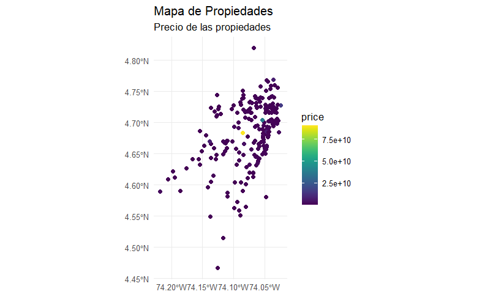

```r
# Crear un mapa utilizando ggplot2 y geom_sf
map <- ggplot(data = sf_house) +
  geom_sf(aes(color = price), size = 2) +
  scale_color_viridis() +
  labs(title = "Mapa de Propiedades",
       subtitle = "Precio de las propiedades",
       color = "price") +
  theme_minimal()

# Guardar el mapa en formato .pdf
ggsave("mapa_propiedades.pdf", plot = map, width = 8, height = 6)

# Mostrar el mapa
print(map)
```

#### Análisis del Mapa

Las propiedades están principalmente concentradas en un área específica, con coordenadas alrededor de 4.45°N a 4.80°N de latitud y 74.05°W a 74.20°W de longitud. Por otro lado, los precios de las propiedades se representan con una escala de color que va desde tonos más claros (amarillo) para los precios más altos hasta tonos más oscuros (púrpura) para los precios más bajos; vemos como las propiedades con los precios más altos están más dispersas, mientras que hay una mayor concentración de propiedades con precios más bajos.

La alta concentración de puntos con colores oscuros indica que la mayoría de las propiedades tienen precios más bajos, mientra que, las propiedades con precios más altos están menos concentradas, lo que sugiere que estos precios elevados podrían estar asociados a características específicas de ciertas propiedades o ubicaciones privilegiadas.

### Analisis Adicionales

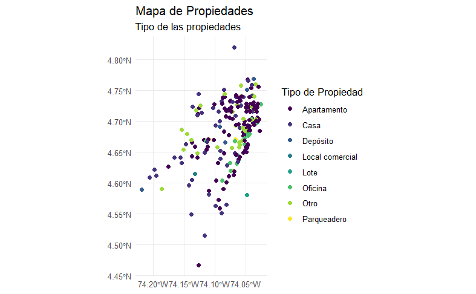

```r
# Convertir 'property_type' a factor
sf_house$property_type <- as.factor(sf_house$property_type)

# Crear un mapa utilizando ggplot2 y geom_sf coloreando por 'property_type'
map <- ggplot(data = sf_house) +
  geom_sf(aes(color = property_type), size = 2) +
  scale_color_viridis(discrete = TRUE) +
  labs(title = "Mapa de Propiedades",
       subtitle = "Tipo de las propiedades",
       color = "Tipo de Propiedad") +
  theme_minimal()

# Guardar el mapa en formato .pdf
ggsave("mapa_propiedades_tipo.pdf", plot = map, width = 8, height = 6)

# Mostrar el mapa
print(map)
```

Distribución de los tipos de propiedades:

Tipos de Propiedades:

Apartamentos (puntos morados): Son el tipo de propiedad más común y están ampliamente distribuidos por toda la zona estudiada, con una alta concentración en el centro.

Depósitos (puntos azules claros): Están presentes pero en una cantidad mucho menor y están más dispersos.

Local Comercial y Oficina (puntos verdes y turquesa): Estos tipos de propiedades parecen estar ubicados en áreas específicas, lo que podría indicar zonas comerciales o de oficinas.